# Homework_2

Yiwen Hua

2026-10-06

## Problem 1

### a

```r
momentum_walk1 <- function(n, p) {
  if (length(n) != 1 || !is.numeric(n) || is.na(n) ||
      n < 1 || n != floor(n)) {
    stop("n must be a positive integer.")
  }

  if (length(p) != 1 || !is.numeric(p) || is.na(p) ||
      p < 0 || p > 1) {
    stop("p must be between 0 and 1.")
  }

  directions <- rbind(
    right = c(1, 0),
    left  = c(-1, 0),
    up    = c(0, 1),
    down  = c(0, -1)
  )

  current_dir <- sample(1:4, 1)
  position <- directions[current_dir, ]

  if (n >= 2) {
    for (i in 2:n) {
      if (runif(1) >= p) {
        current_dir <- sample(1:4, 1)
      }
      position <- position + directions[current_dir, ]
    }
  }

  return(as.numeric(position))
}
```

### b

```r
momentum_walk2 <- function(n, p) {
  if (length(n) != 1 || !is.numeric(n) || is.na(n) ||
      n < 1 || n != floor(n)) {
    stop("n must be a positive integer.")
  }

  if (length(p) != 1 || !is.numeric(p) || is.na(p) ||
      p < 0 || p > 1) {
    stop("p must be between 0 and 1.")
  }

  directions <- rbind(
    right = c(1, 0),
    left  = c(-1, 0),
    up    = c(0, 1),
    down  = c(0, -1)
  )

  current_dir <- sample(1:4, 1)

  steps <- sapply(seq_len(n), function(i) {
    if (i > 1 && runif(1) >= p) {
      current_dir <<- sample(1:4, 1)
    }
    directions[current_dir, ]
  })

  return(as.numeric(rowSums(steps)))
}
```

Now we run the test to see the outcome

```r
momentum_walk1(10, 0.6)
```

```
## [1] -2  0
```

```r
momentum_walk2(10, 0.6)
```

```
## [1] 4 0
```

```r
momentum_walk1(1000, 0.6)
```

```
## [1] 35 79
```

```r
momentum_walk2(1000, 0.6)
```

```
## [1] -31   9
```

momentum_walk1() uses a for loop to generate the walk sequentially. At each step after the first, the previous direction is preserved with probability p; otherwise a new direction is sampled uniformly from the four possible directions. momentum_walk2() implements the same sequential update using sapply() and sums the resulting displacement vectors to obtain the final position.

### c

```r
set.seed(506)
momentum_walk1(10, 0.6)
```

```
## [1] -2  0
```

```r
set.seed(506)
momentum_walk1(10, 0.6)
```

```
## [1] -2  0
```

```r
set.seed(506)
momentum_walk1(1000, 0.6)
```

```
## [1] -14 -30
```

```r
set.seed(506)
momentum_walk1(1000, 0.6)
```

```
## [1] -14 -30
```

I used set.seed(506) before each simulation. Setting the same seed resets R’s random-number generator to the same initial state, so the same sequence of random numbers is generated and the simulation produces the same final position.

### d

```r
set.seed(506)

p_values <- c(0, 0.5, 0.9)

final_positions <- sapply(
  p_values,
  function(p) momentum_walk1(1000, p)
)

distances <- sqrt(colSums(final_positions^2))

data.frame(
  p = p_values,
  distance = distances
)
```

```
##     p  distance
## 1 0.0  23.19483
## 2 0.5  62.28965
## 3 0.9 157.00318
```

In these three simulations, the final distance generally tends to be larger for higher momentum. However, since each value of p is represented by only one random walk, these individual simulations are not sufficient to determine typical behavior.

### e

```r
set.seed(506)

p_values <- c(0, 0.25, 0.5, 0.75, 0.9)

mean_distances <- sapply(p_values, function(p) {

  distances <- replicate(1000, {
    pos <- momentum_walk1(1000, p)
    sqrt(sum(pos^2))
  })

  mean(distances)
})

mc_results <- data.frame(
  p = p_values,
  mean_distance = mean_distances
)

mc_results
```

```
##      p mean_distance
## 1 0.00      27.75439
## 2 0.25      36.24280
## 3 0.50      48.41756
## 4 0.75      75.69467
## 5 0.90     122.89538
```

The mean final distance increases as p increases. Higher momentum makes consecutive steps more persistent in the same direction, so the walk tends to travel farther from its starting point.

### f

```r
library(microbenchmark)

bench_1000 <- microbenchmark(
  loop = momentum_walk1(1000, 0.6),
  apply = momentum_walk2(1000, 0.6),
  times = 100
)
bench_1000
```

```
## Unit: milliseconds
##   expr      min       lq     mean   median       uq      max neval
##   loop 1.352344 1.438423 1.532198 1.473212 1.518845 2.350858   100
##  apply 1.637335 1.773660 1.875058 1.830896 1.872737 2.704975   100
```

```r
bench_100000 <- microbenchmark(
  loop = momentum_walk1(100000, 0.6),
  apply = momentum_walk2(100000, 0.6),
  times = 10
)

bench_100000
```

```
## Unit: milliseconds
##   expr      min       lq     mean   median       uq      max neval
##   loop 153.7992 155.7324 158.9221 157.9871 158.7586 174.1141    10
##  apply 190.3510 193.0007 204.6132 199.6221 208.5205 245.5059    10
```

momentum_walk1 was faster for both input sizes. The absolute difference became larger for $n=100000$, likely because sapply() introduces additional function-call and intermediate-object overhead.

## Problem 2

```r
set.seed(506)

n_days <- 10000

morning <- rowSums(matrix(
  rpois(n_days * 3, lambda = 4),
  nrow = n_days
))

peak_morning <- rnorm(
  n_days, mean = 45, sd = 4
)

midday <- rowSums(matrix(
  rpois(n_days * 6, lambda = 15),
  nrow = n_days
))

peak_afternoon <- rnorm(
  n_days, mean = 55, sd = 5
)

evening <- rowSums(matrix(
  rpois(n_days * 6, lambda = 9),
  nrow = n_days
))

daily_total <- morning + peak_morning +
               midday + peak_afternoon + evening

mean(daily_total)
```

```
## [1] 256.1777
```

Based on 10,000 simulated days, the estimated expected number of passengers per day is approximately 256.1777. This is close to 256 passengers per day.

## Problem 3

```r
youtube <- read.csv(
  "https://raw.githubusercontent.com/rfordatascience/tidytuesday/master/data/2021/2021-03-02/youtube.csv"
)

names(youtube)
```

```
##  [1] "year"                      "brand"
##  [3] "superbowl_ads_dot_com_url" "youtube_url"
##  [5] "funny"                     "show_product_quickly"
##  [7] "patriotic"                 "celebrity"
##  [9] "danger"                    "animals"
## [11] "use_sex"                   "id"
## [13] "kind"                      "etag"
## [15] "view_count"                "like_count"
## [17] "dislike_count"             "favorite_count"
## [19] "comment_count"             "published_at"
## [21] "title"                     "description"
## [23] "thumbnail"                 "channel_title"
## [25] "category_id"
```

```r
dim(youtube)
```

```
## [1] 247  25
```

```r
youtube_clean <- youtube[, !names(youtube) %in% c(
  "brand",
  "superbowl_ads_dot_com_url",
  "youtube_url",
  "id",
  "kind",
  "etag",
  "published_at",
  "title",
  "description",
  "thumbnail",
  "channel_title",
  "category_id"
)]

dim(youtube_clean)
```

```
## [1] 247  13
```

```r
names(youtube_clean)
```

```
##  [1] "year"                 "funny"                "show_product_quickly"
##  [4] "patriotic"            "celebrity"            "danger"
##  [7] "animals"              "use_sex"              "view_count"
## [10] "like_count"           "dislike_count"        "favorite_count"
## [13] "comment_count"
```

I removed variables that could directly identify a particular commercial, including the brand, URLs, video identifiers and metadata, publication information, title, description, thumbnail, and channel information. The resulting dataset has 247 observations and 13 variables.

### b

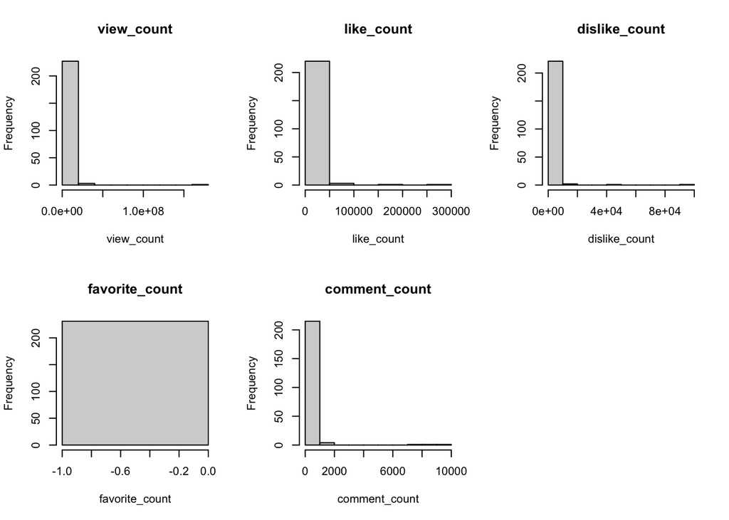

```r
outcomes <- c(
  "view_count",
  "like_count",
  "dislike_count",
  "favorite_count",
  "comment_count"
)

par(mfrow = c(2, 3))

for (v in outcomes) {
  hist(
    youtube_clean[[v]],
    main = v,
    xlab = v
  )
}

par(mfrow = c(1, 1))
```

```r
summary(youtube_clean[outcomes])
```

```
##    view_count          like_count     dislike_count     favorite_count
##  Min.   :       10   Min.   :     0   Min.   :    0.0   Min.   :0
##  1st Qu.:     6431   1st Qu.:    19   1st Qu.:    1.0   1st Qu.:0
##  Median :    41379   Median :   130   Median :    7.0   Median :0
##  Mean   :  1407556   Mean   :  4146   Mean   :  833.5   Mean   :0
##  3rd Qu.:   170016   3rd Qu.:   527   3rd Qu.:   24.0   3rd Qu.:0
##  Max.   :176373378   Max.   :275362   Max.   :92990.0   Max.   :0
##  NAs    :16          NAs    :22       NAs    :22        NAs    :16
##  comment_count
##  Min.   :   0.00
##  1st Qu.:   1.00
##  Median :  10.00
##  Mean   : 188.64
##  3rd Qu.:  50.75
##  Max.   :9190.00
##  NAs    :25
```

```r
sapply(youtube_clean[outcomes], function(x) {
  c(
    min = min(x, na.rm = TRUE),
    median = median(x, na.rm = TRUE),
    mean = mean(x, na.rm = TRUE),
    max = max(x, na.rm = TRUE),
    zeros = sum(x == 0, na.rm = TRUE),
    missing = sum(is.na(x))
  )
})
```

```
##         view_count like_count dislike_count favorite_count comment_count
## min             10      0.000        0.0000              0        0.0000
## median       41379    130.000        7.0000              0       10.0000
## mean       1407556   4146.031      833.5378              0      188.6396
## max      176373378 275362.000    92990.0000              0     9190.0000
## zeros            0      9.000       47.0000            231       41.0000
## missing         16     22.000       22.0000             16       25.0000
```

```r
youtube_clean$log_view_count <- log1p(youtube_clean$view_count)
youtube_clean$log_like_count <- log1p(youtube_clean$like_count)
youtube_clean$log_dislike_count <- log1p(youtube_clean$dislike_count)
youtube_clean$log_comment_count <- log1p(youtube_clean$comment_count)
```

view_count, like_count, dislike_count, and comment_count are highly right-skewed, so I classified them as category 2 and applied $\log(1+x)$. favorite_count has no variation among its observed values, so I classified it as category 3.

### c

```r
outcomes <- c(
  "log_view_count",
  "log_like_count",
  "log_dislike_count",
  "log_comment_count"
)

# Seven binary characteristics
characteristics <- c(
  "funny",
  "show_product_quickly",
  "patriotic",
  "celebrity",
  "danger",
  "animals",
  "use_sex"
)

# Fit one model for each outcome-characteristic combination
results_list <- lapply(outcomes, function(outcome) {

  outcome_results <- lapply(characteristics, function(characteristic) {

    # Construct regression formula:
    # outcome ~ characteristic + year
    formula_i <- as.formula(
      paste(outcome, "~", characteristic, "+ year")
    )

    # Fit linear regression
    fit_i <- lm(formula_i, data = youtube_clean)

    # Extract coefficient table
    coef_table <- summary(fit_i)$coefficients

    # The second row corresponds to the binary characteristic
    data.frame(
      outcome = outcome,
      characteristic = characteristic,
      estimate = coef_table[2, "Estimate"],
      p_value = coef_table[2, "Pr(>|t|)"],
      stringsAsFactors = FALSE
    )
  })

  do.call(rbind, outcome_results)
})

# Combine all results into one data frame
results <- do.call(rbind, results_list)

# Remove row names for cleaner output
rownames(results) <- NULL

# Display all regression results
results
```

```
##              outcome       characteristic    estimate    p_value
## 1     log_view_count                funny  0.52984356 0.20510610
## 2     log_view_count show_product_quickly  0.20898031 0.60072225
## 3     log_view_count            patriotic  0.13692497 0.78391866
## 4     log_view_count            celebrity -0.01898556 0.96288885
## 5     log_view_count               danger  0.66678076 0.09406479
## 6     log_view_count              animals -0.17326980 0.64669142
## 7     log_view_count              use_sex -0.29629543 0.49051595
## 8     log_like_count                funny  0.36019066 0.34005646
## 9     log_like_count show_product_quickly  0.16825538 0.64047730
## 10    log_like_count            patriotic  0.49311233 0.28968290
## 11    log_like_count            celebrity  0.26297830 0.47787826
## 12    log_like_count               danger  0.62526219 0.08031647
## 13    log_like_count              animals  0.02459257 0.94282914
## 14    log_like_count              use_sex -0.32497453 0.40008928
## 15 log_dislike_count                funny  0.04148774 0.89580597
## 16 log_dislike_count show_product_quickly  0.24290875 0.42097425
## 17 log_dislike_count            patriotic  0.66965405 0.08563747
## 18 log_dislike_count            celebrity -0.28325315 0.36162721
## 19 log_dislike_count               danger  0.18514931 0.53794989
## 20 log_dislike_count              animals -0.07378053 0.79742453
## 21 log_dislike_count              use_sex -0.38888066 0.22927926
## 22 log_comment_count                funny  0.04746590 0.87934573
## 23 log_comment_count show_product_quickly  0.34602814 0.24685774
## 24 log_comment_count            patriotic  0.51478460 0.16854269
## 25 log_comment_count            celebrity  0.22806291 0.45558834
## 26 log_comment_count               danger  0.10642262 0.72095533
## 27 log_comment_count              animals -0.19176266 0.49906680
## 28 log_comment_count              use_sex -0.34939714 0.27353634
```

```r
# Statistically significant associations at alpha = 0.05
significant_results <- results[
  !is.na(results$p_value) & results$p_value < 0.05,
]

significant_results
```

```
## [1] outcome        characteristic estimate       p_value
## <0 rows> (or 0-length row.names)
```

```r
# Results for view count only
view_results <- results[
  results$outcome == "log_view_count",
]

# Sort by p-value
view_results_sorted <- view_results[
  order(view_results$p_value),
]

view_results_sorted
```

```
##          outcome       characteristic    estimate    p_value
## 5 log_view_count               danger  0.66678076 0.09406479
## 1 log_view_count                funny  0.52984356 0.20510610
## 7 log_view_count              use_sex -0.29629543 0.49051595
## 2 log_view_count show_product_quickly  0.20898031 0.60072225
## 6 log_view_count              animals -0.17326980 0.64669142
## 3 log_view_count            patriotic  0.13692497 0.78391866
## 4 log_view_count            celebrity -0.01898556 0.96288885
```

```r
# Characteristic with the largest positive estimated
# association with view count
largest_positive_view <- view_results[
  which.max(view_results$estimate),
]

largest_positive_view
```

```
##          outcome characteristic  estimate    p_value
## 5 log_view_count         danger 0.6667808 0.09406479
```

```r
# Characteristic with the smallest p-value for view count
smallest_p_view <- view_results[
  which.min(view_results$p_value),
]

smallest_p_view
```

```
##          outcome characteristic  estimate    p_value
## 5 log_view_count         danger 0.6667808 0.09406479
```

```r
best_characteristic <- smallest_p_view$characteristic

best_characteristic
```

```
## [1] "danger"
```

None of the commercial characteristics were significantly associated with the four outcomes at $\alpha=0.05$. For log view count, danger had the largest positive coefficient (0.667), although it was not significant ($p=0.094$).

### d

```r
d_data <- youtube_clean[
  complete.cases(
    youtube_clean$log_view_count,
    youtube_clean$danger,
    youtube_clean$year
  ),
]

y <- d_data$log_view_count

X <- cbind(
  intercept = 1,
  danger = as.numeric(d_data$danger),
  year = d_data$year
)

beta_hat <- solve(
  t(X) %*% X,
  t(X) %*% y
)

beta_hat
```

```
##                   [,1]
## intercept -31.39149243
## danger      0.66678076
## year        0.02065641
```

```r
fit_lm <- lm(
  log_view_count ~ danger + year,
  data = d_data
)

coef(fit_lm)
```

```
##  (Intercept)   dangerTRUE         year
## -31.39149243   0.66678076   0.02065641
```

```r
cbind(
  matrix_algebra = as.numeric(beta_hat),
  lm = as.numeric(coef(fit_lm))
)
```

```
##      matrix_algebra           lm
## [1,]   -31.39149243 -31.39149243
## [2,]     0.66678076   0.66678076
## [3,]     0.02065641   0.02065641
```

```r
all.equal(
  as.numeric(beta_hat),
  as.numeric(coef(fit_lm)),
  tolerance = 1e-10
)
```

```
## [1] TRUE
```

danger had the smallest p-value for log view count in part (c). Using $\hat\beta=(X^TX)^{-1}X^Ty$, the estimated coefficients matched those from lm() up to numerical precision.